# Who Really is the Best Basketball Player?

Jacob Grant

May 18, 2019

# 1) Introduction

The goal of this analysis is to determine the best statistical basketball player of all time not including awards or championships earned/won by the player, but solely his performance on the basketball court. The data set used comes from https://www.basketball-reference.com/players/ and the specific basketball players included in the study come from a previous ranking of the top 100 basketball players (in order to narrow our search a bit) https://bleacherreport.com/articles/2232060-br-nba-legends-100-ranking-the-greatest-players-of-all-time#slide101. The goal of this study is to take these basketball players and re-rank them based solely on their statistical performance. A few ranking methodologies are used: 1) Ranking all players based on total points scored, assists and rebounds 2) Ranking all players based on total points scored, assists and rebounds but by attempting to standardize each given statistic in order to fairly compare time periods 3) Using some advanced statistical methods to delve deeper into player performance

The stats included in this data set are Season, Age, Team(Tm), League(Lg), Position(Pos), Games(G), Games Started(GS), Minutes Played(MP), Field Goals(FG), Field Goals Attempted(FGA), Field Goal Percentage(FG%), 3 Pointerss Made(3P), 3 Pointerss Attempted(3PA), 3 Point Percentage(3P%), 2 Pointers Made(2P), 2 Pointers Attempted(2PA), 2 Pointer Percentage(2P%), Effective Field Goal Percentage(eFG%), Free Thorws(FT), Free Throws Attempted(FTA), Field Throw Percentage(FT%), Offensive Rebounds(ORB), Defensive Rebounds(DRB), Total Rebounds(TRB), Assists(AST), Steals(STL), Blocks(BLK), Turn Overs(TOV), Fouls(PF), Points(PTS). More information about data collection and attribute meanings can be seen at https://www.basketball-reference.com/about/glossary.html?lid=header_morelinks

# 2) Scraping the Data

Here we gather the statistical data for 100 of the best basketball players of all time. First, the names of the 100 best basketball players are scraped to determine which stats we need to gather. Then, a url is generated corresponding to a specific player from the website BasketBallReference where the statistical data is scraped. The resulting data is then combined into one large data set for use in the analysis.

# 3) Initial Data Analysis

## 3a) Scoring Comparison

We all know that whoever scores the most points wins the game. So, naturally, whoever scores the most points must be the best player, right? Because scoring is one of the most important statistics in basketball and thus very important in determining who is the best basketball player, the following charts will compare the best scorers the league has ever seen

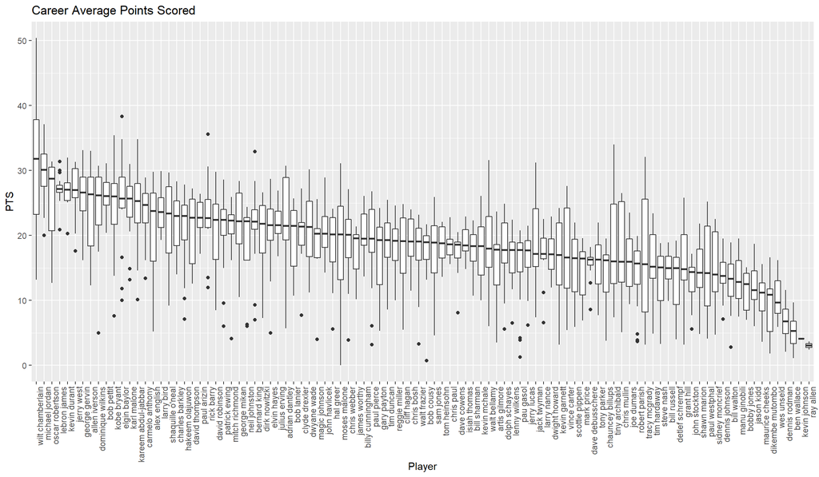

It may be temping to conclude that Wilt Chamberlain is the greatest scorer of all time as he has the highest average score and also the highest upper quartile. However, it is important to note that often a player struggles during his first two seasons in the NBA, as he gets adjusted to the difficulty, and then begins to thrive. Many players thus have lower scoring averages for their first two years, driving down their otherwise stellar numbers. Lets factor out those first two years and see if anything changes

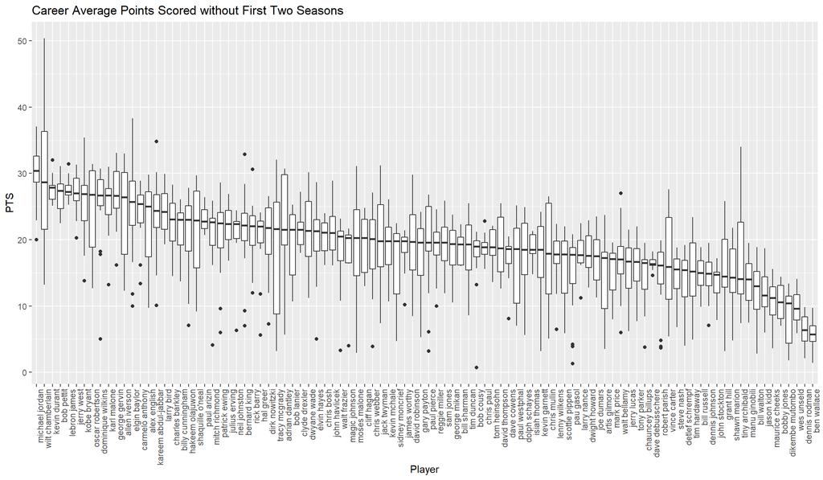

Comparing these two graphs, we see that most players underwent some change in average points scored as expected and thus the categorical x values are in a different order. For example, now Michael Jordan is the greatest scorer of all time. As discussed earlier, scoring is not the only important statistic that should be considered when determining the best player. Two other common statistics that are used in the NBA for comparing players are assists and rebounds. Assists means that the player passed the ball to another teammate who immediately scored, meaning that the player is a team-player. A rebound means that the player caught the ball after a shot was missed by either their own teammate or another team’s player, meaning the player hussles. We could do a similar analysis as above by ordering the average assists for each player and the average rebounds for each player.

## 3b) Assists Comparison

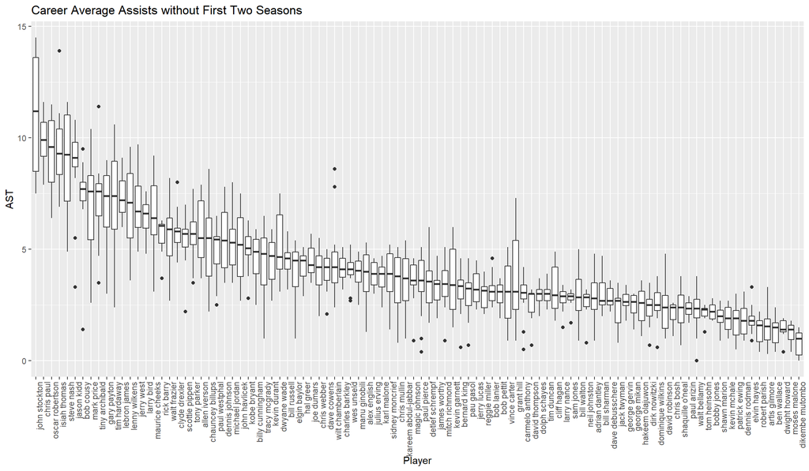

## 3c) Rebound Comparison

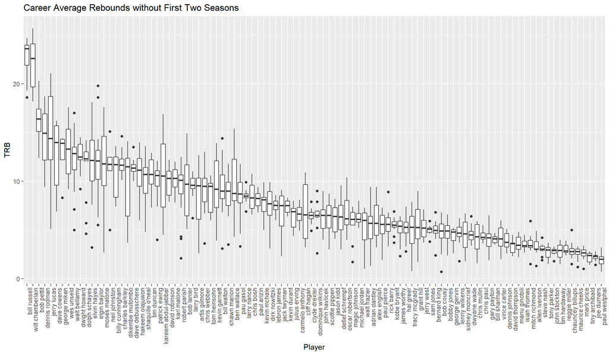

Now that we have rankings of the best scorers, assisters and rebounders in the league (based on career averages)…it seems reasonable that the player with the lowest overall score (adding their ranking for each) should be the best player

## 3d) Initial Ranking

First 10 Rankings of 100 of the Best Basketball Players

| Player | Ranking | Score_Rank | Assist_Rank | Rebound_Rank | Overall_Score |
| --- | --- | --- | --- | --- | --- |
| wilt chamberlain | 1 | 2 | 30 | 2 | 34 |
| lebron james | 2 | 4 | 7 | 43 | 54 |
| larry bird | 3 | 14 | 15 | 29 | 58 |
| oscar robertson | 4 | 12 | 4 | 46 | 62 |
| elgin baylor | 5 | 11 | 41 | 11 | 63 |
| charles barkley | 6 | 20 | 37 | 12 | 69 |
| bob pettit | 7 | 6 | 65 | 3 | 74 |
| billy cunningham | 8 | 24 | 31 | 21 | 76 |
| karl malone | 9 | 9 | 47 | 22 | 78 |
| michael jordan | 10 | 1 | 24 | 55 | 80 |

# 4) Standardized Ranking

First 10 Rankings of 100 of the Best Basketball Players Standardized

| Player | Ranking | Score_Rank | Assist_Rank | Rebound_Rank | Overall_Score |
| --- | --- | --- | --- | --- | --- |
| lebron james | 1 | 3 | 9 | 27 | 39 |
| wilt chamberlain | 2 | 6 | 33 | 3 | 42 |
| larry bird | 3 | 14 | 15 | 15 | 44 |
| kevin durant | 4 | 1 | 29 | 29 | 59 |
| charles barkley | 5 | 19 | 42 | 6 | 67 |
| karl malone | 6 | 8 | 49 | 19 | 76 |
| kobe bryant | 7 | 4 | 26 | 48 | 78 |
| michael jordan | 8 | 2 | 27 | 51 | 80 |
| kareem abdul-jabbar | 9 | 12 | 47 | 23 | 82 |
| chris paul | 10 | 28 | 2 | 59 | 89 |

Comparing the ranking table above with the one in section 3d, we can see that standardizing points, assists and rebounds has changed our ranking order. For example, now lebron james is the number one ranked player of all time instead of wilt chamberlain. This indicates that lebron, over his entire career, was more dominant against his current competition in the 3 categories of importance than wilt chamberlain. Additionally, we see the rise of Kevin Durant who, over his career, has dominated scoring more than any other player. Finally, we see that Michael Jordan has risen slightly from his previous ranking of 10 to a new raking of 8. The results of this table are meant to showcase the final result of standardizing each important statistic in order for us to fairly compare years. While this is a good idea in theory, the above analysis has two main flaws, the second of which we will address in the following section. The first problem is that we dont have enough data to fairly standardize each statistic. Because we scraped data from a previous ranking of the top 100 basketball players of all time, there is no reason to assume that each year is fairly represented. For example, we may be lacking data from 1960 while we have abundant data from 2000. Therefore, we may not be standardizing against the correct mean and variance, resulting in incorrect standardization. To remedy this problem, we would need the true average and standard deviations from every year to standardize against. The second problem, which we will address next as it is more pressing, is that basketball is much more intricate than these 3 simple statistics. In order to better rank players, we will use advanced statistics to delve deeper into each players on-court impact.

# 5) Advanced Statistic Ranking

## 5a) Efficiency Rating

The goal of the following analysis will be to rank players by their efficiency. The classic formula for efficiency was created by statistian Martin Manley (read more here https://www.nba.com/statistics/efficiency.html) and follows the following formula of EFF = (Points + Rebounds + Assists + Steals + Blocks) - ((Field Goals Att. - Field Goals Made) + (Free Throws Att. - Free Throws Made) + Turnovers)). This statistic has been used to quantify how impactful a player is by measuring their contribution to a wealth of different parts of the game. There is a glaring problem, however: the NBA did not start recording Steals until 1973, Turnovers until 1977 and Blocks until 1973. Therefore, we will impute these missing values with the average value so players can be compared more evenly.

First 10 Rankings of 100 of the Best Basketball Players Efficiencies

| Player | Avg_EFF |
| --- | --- |
| wilt chamberlain | 40.23743 |
| bill russell | 31.89068 |
| bob pettit | 31.36442 |
| kareem abdul-jabbar | 29.75395 |
| oscar robertson | 29.73215 |
| lebron james | 29.60714 |
| larry bird | 29.54545 |
| michael jordan | 28.81538 |
| kevin durant | 28.47000 |
| charles barkley | 28.26429 |

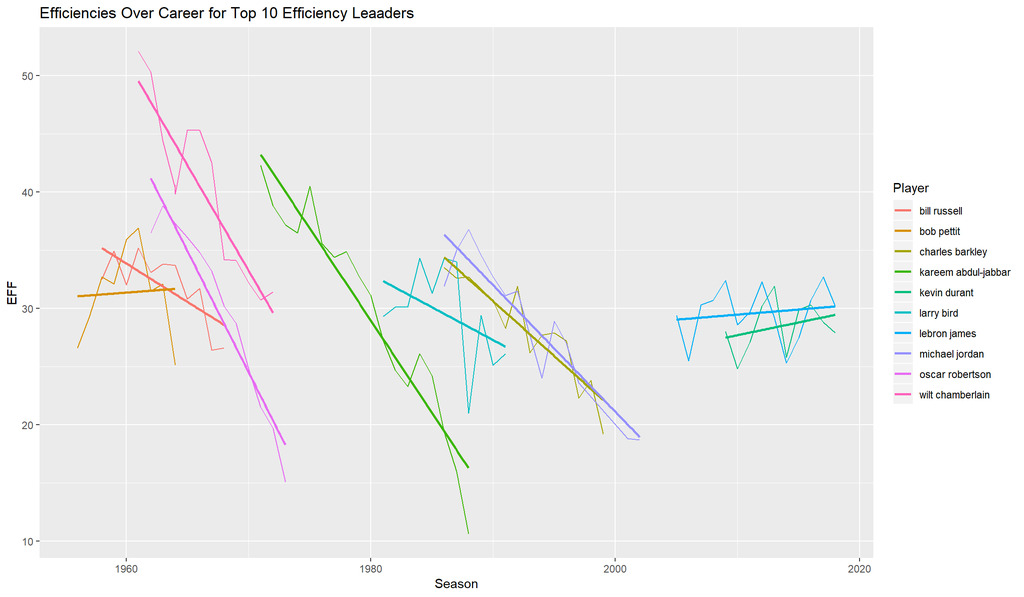

```
## # A tibble: 2 x 5
##   term        estimate std.error statistic p.value
##   <chr>          <dbl>     <dbl>     <dbl>   <dbl>
## 1 (Intercept) -412.      492.       -0.838   0.426
## 2 Season         0.219     0.244     0.896   0.396
## # A tibble: 2 x 5
##   term         estimate std.error statistic p.value
##   <chr>           <dbl>     <dbl>     <dbl>   <dbl>
## 1 (Intercept) -146.       316.       -0.462   0.652
## 2 Season         0.0873     0.157     0.556   0.588
```

New First 10 Rankings of 100 of the Best Basketball Players Efficiencies

| Player | Avg_EFF |
| --- | --- |
| wilt chamberlain | 40.23743 |
| bill russell | 31.89068 |
| bob pettit | 31.36442 |
| lebron james | 29.83204 |
| kareem abdul-jabbar | 29.75395 |
| oscar robertson | 29.73215 |
| larry bird | 29.54545 |
| michael jordan | 28.81538 |
| kevin durant | 28.49879 |
| charles barkley | 28.26429 |

We see that the p value for the variable ‘Season’ is above our threshold of 0.05 for both lebron james (0.588) and kevin durant (.396). This means that the change in EFF per season for these two players is not statistically significant enough to say the value is not actually zero and thus does not pass the null hypothesis. However, on average, in this dataset (which is only a sample of the population) the average EFF of each player will increase in the next 5 years if they continue at this level. Lebron James, in fact, goes from the 6th highest efficiency to the 4th highest efficiency. However, there are several glaring problems when ranking players by efficiencies. What about 3 point contribution? What about the increased difficulty of getting offensive rebounds versus defensive rebounds? How much does the player dominante these statistics on his own team? These questions can be answere by using a newer advanced metric (more information here: https://stats.nba.com/help/glossary/#pie) for rating players and then doing a bit of an adjustment (to include the increased difficulty of 3 point field goals). As stated in the link, PIE “shows what % of game events that player acheived,” meaning a better player accounts for a higher percentage of his teams game events. The formula (slightly adjusted) is as follows…(PTS + 2PtFG + .5*3PtFG - 2PtFGA -.5(3PtFGA) + FT - FTA + DREB + (.5ORB) + AST + STL + (.5BLK) - PF - TOV) / (TeamPTS + Team2PtFG + .5(Team3PtFG) - Team2PtFGA -.5(Team3PtFGA) + TeamFT - TeamFTA + TeamDREB + (.5TeamOREB) + TeamAST + TeamSTL + (.5TeamBLK) - TeamPF - TeamTOV). This formula not only considers a players impact, but also considers his relative impact to his team, an important metric that we have not considered yet. In order to implement this formula, we need more data (the previous data set does not include Team Stats which we will need for calculating PIE). We will pull data from the website https://www.basketball-reference.com/teams/ and implement the formula. However, we run into a few problems, as mentioned before, with missing values for Steals, Blocks, 3 point FG (not invented until 1979), TOV, TeamORB and TeamDRB. To solve this, we will use a slightly modified PIE that will apply to these situations (before 1979). PIE = (PTS + FG - FGA + FT - FTA + 0.75(TRB) + AST - PF) / (TeamPTS + TeamFG - TeamFGA + TeamFT - TeamFTA + 0.75(TeamTRB) + TeamAST - TeamPF)

## 5b) Improved Player Efficiency

First 10 Rankings of 100 of the Best Basketball Players PIE

| Player | Avg_PIE |
| --- | --- |
| wilt chamberlain | 33.31444 |
| lebron james | 29.64116 |
| michael jordan | 27.69251 |
| bob pettit | 26.99335 |
| kevin durant | 26.24771 |
| larry bird | 25.95829 |
| oscar robertson | 25.66494 |
| karl malone | 25.59185 |
| charles barkley | 25.55107 |
| bill russell | 24.74380 |

The above chart shows our final ranking, showing the top ten average player impact efficiencies (PIE). Clearly, Wilt Chamberlain is still the highest ranking, ranking 4% above second place lebron james meaning that he accounts for 4% more of the total game events than lebron james does. However, Michael Jordan has significantly increased his ranking (compared to our previous rankings) as clearly he has a realtively larger impact on his team than the other rankings allowed us to see. We also interestingly see the rise of Bob Pettit whom is seldom talked about in the best basketball players of all time, but because he accounted for over a quarter of his teams game events has risen in our rankings.

# 6) Conclusion

This analysis has tried to determine the best basketball of all time using a pure statistics approach (not considering awards or team accomplishments). As is clear by the amount of rankings presented in this analysis, it is difficult to determine (without introducing personal bias) the correct way to rank players due to a few reasons: lack of data before 1979, the addition of the three point line, and the quality of competition increase. We first looked at only points, assists and rebounds (excluding rookie seasons) as a metric for ranking but determined that comparing these statsitics across years is unfair We then tried to standardize points, assists and rebounds with the surrounding 5 years of data in order to better compare different time periods but determined that only ranking based on these three statistics is inadequate. We then analyzed through the lens of advanced statistics: Efficiency and Player Efficiency Impact. Ranking with respect to efficiencies provided a more complete picture of the players performance across several metrics, but failed to include important statistics such as shooting ability and team impact. To remedy this, we instead looked at Player Efficiency Impact which uses a denominator to compare the players stats to his entire team and includes three point shooting. This percentage details what amount of team events the player took part in, with a higher number indicating a more dominant player. While this may have been our best attempt yet at ranking players, there are still a few holes due to PIE’s offensive leaning nature (neglecting to take into account the players plus-minus https://www.basketball-reference.com/about/bpm.html). Other even more all encompassing statistics exist, such as PER and RAPM, which an interested reader can read more about here https://www.basketball-reference.com/about/per.html and https://www.nbastuffer.com/analytics101/regularized-adjusted-plus-minus-rapm/. In conclusion, after reading this analysis, we leave it up to the reader to determine which ranking he/she believes is best after presenting advantages and disadvantages of each ranking.

# 7) Code

Part 2

```r
url <- "https://bleacherreport.com/articles/2232060-br-nba-legends-100-ranking-the-greatest-players-of-all-time#slide86"
best_players <- data.frame("Player"=1:100)
i <- 3
#This loop scrapes the names of the basketball players from the url above and places them in an array.
while (i <= 102) {
  entry <- paste(c("#slide", i), collapse = "")
  player <- read_html(url) %>%
    html_node(entry) %>%
    html_node("h1") %>%
    html_text()

  best_players$Player[i-2] <- str_extract(sapply(str_replace_all(str_replace_all(player, "[0-9]", ""), "\\.", ""),tolower), "[A-z].*$")
  i <- i + 1
}

#This is simply used for ease of getting the attribute names
url <- "https://www.basketball-reference.com/players/j/jordami01.html"
mJordan <- read_html(url) %>%
  html_node(".stats_table") %>%
  html_table() %>%
  as_tibble()
mJordan <- mJordan %>%
  filter(Lg == "NBA" & is.na(Age) == FALSE)

i <- 1
data <- mJordan
data$Player <- NA
data <- data[0,]
#This loop takes all of the players previously collected, crafts a url based on their name, and pulls data from the above url. The data is then processed (removing the career averages column) and then added into the large data collection frame called "data"
while (i <= length(best_players$Player)) {
  curr_player <- best_players$Player[i]
  last_name <- str_extract(curr_player, "([A-z]*)$")
  if (str_length(last_name) >= 6) {
    last_name <- str_sub(last_name, 1, 5)
  }
  if (last_name == "neal") {
    last_name = "oneal"
  } else if (last_name == "jabba") {
    last_name = "abdul"
  }
  #Constructing the url to scrape data from
  first_name <- substring(curr_player, 1, 2)
  ending <- paste(last_name, first_name, sep = "")
  ending <- paste(ending, '01.html', sep = "")
  first_part <- paste("/",substring(last_name, 1, 1), sep = "")
  first_part <- paste(first_part, "/", sep = "")
  ending <- paste(first_part, ending, sep = "")
  url <- paste("https://www.basketball-reference.com/players", ending, sep = "")

  #Getting the data
  newData <- read_html(url) %>%
    html_node(".stats_table") %>%
    html_table() %>%
    as_tibble()

  #Removing unnecessary rows
  newData$Player <- rep(curr_player, nrow(newData))
  newData <- newData %>%
    filter(Lg == "NBA" & is.na(Age) == FALSE)

  data <- rbind.fill(data, newData)

  i <- i + 1
}
i <- 1
#removing the second part of season to help with standardizing later on
while (i<= nrow(data)) {
  data$Season[i] <- str_extract(data$Season[i], "^[0-9]*")
  i <- i + 1
}

#rearranging the columns and changing data types
data <- data[,c(31,1:30)]
data[7:31] <-lapply(data[7:31], as.numeric)
data[2] <-lapply(data[2], as.numeric)
data[is.na(data)] <- 0.0
```

Part 3a

```r
#This plot is a box plot showing the spread of total points for every player ordered by median value, considering their entire career.
data %>%
  group_by(Player) %>%
  ggplot(aes(x = reorder(Player, -PTS, FUN = median), y = PTS)) +
    geom_boxplot() +
    theme(axis.text.x = element_text(angle = 90, hjust = 1))+
    ggtitle("Career Average Points Scored") +
    xlab("Player")
```

```r
i <- 1
j <- 1
rows_remove = c()
#This loop find every players first and second years, and removes them from the data. All of the following analyses will be done with this rookie removed data
while (i < nrow(data)) {
  curr_Player <- data$Player[i]
  if (j == 1 || j == 2) {
    rows_remove <- append(rows_remove, i)
  }
  if (data$Player[i+1] != curr_Player) {
    j <- 1
  } else {
    j <- j + 1
  }
  i <- i + 1
}

#This plot is a box plot showing the spread of total points for every player ordered by median value with the first two years removed.
data_no_rookies <- data[-rows_remove,]
data <- as_tibble(data)
data_no_rookies <- as_tibble(data_no_rookies)
data_no_rookies %>%
  group_by(Player) %>%
  ggplot(aes(x = reorder(Player, -PTS, FUN = median), y = PTS)) +
    geom_boxplot() +
    theme(axis.text.x = element_text(angle = 90, hjust = 1))+
    ggtitle("Career Average Points Scored without First Two Seasons") +
    xlab("Player")
```

Part 3b

```r
#This plot is a box plot showing the spread of total assists  for every player ordered by median value with the first two years removed
data_no_rookies %>%
  group_by(Player) %>%
  ggplot(aes(x = reorder(Player, -AST, FUN = median), y = AST)) +
    geom_boxplot() +
    theme(axis.text.x = element_text(angle = 90, hjust = 1))+
    ggtitle("Career Average Assists without First Two Seasons") +
    xlab("Player")
```

Part 3c

```r
#This plot is a box plot showing the spread of total rebounds (offensive rebounds + defensive rebounds) for every player ordered by median value with the first two years removed
data_no_rookies %>%
  group_by(Player) %>%
  ggplot(aes(x = reorder(Player, -TRB, FUN = median), y = TRB)) +
    geom_boxplot() +
    theme(axis.text.x = element_text(angle = 90, hjust = 1))+
    ggtitle("Career Average Rebounds without First Two Seasons") +
    xlab("Player")
```

Part 3d

```r
#Ranking the top players by averaging their points, assists and rebounds over their entire career and then comparing to other players.
top_scorers <- data_no_rookies %>%
  group_by(Player) %>%
  dplyr::summarise(Avg_Career_Points=mean(PTS))
top_scorers <- top_scorers[order(-top_scorers$Avg_Career_Points),]

top_assisters <- data_no_rookies %>%
  group_by(Player) %>%
  dplyr::summarise(Avg_Career_Assists=mean(AST))
top_assisters <- top_assisters[order(-top_assisters$Avg_Career_Assists),]

top_rebounders <- data_no_rookies %>%
  group_by(Player) %>%
  dplyr::summarise(Avg_Career_Rebounds=mean(TRB))
top_rebounders <- top_rebounders[order(-top_rebounders$Avg_Career_Rebounds),]

ranking <- data.frame("Player" = top_scorers$Player, "Score_Rank" = 0, "Assist_Rank" = 0, "Rebound_Rank" = 0, "Overall_Score" = 0)

#This actually determines their rank relative to other players by computing total score (point rank + assist rank + rebound rank)
i <- 1
while (i<=nrow(top_assisters)) {
  curr_Player = ranking$Player[i]
  j <- 1
  while (top_scorers$Player[j] != curr_Player) {
    j <- j + 1
  }
  ranking$Score_Rank[i] <- j

  j <- 1
  while (top_assisters$Player[j] != curr_Player) {
    j <- j + 1
  }
  ranking$Assist_Rank[i] <- j

  j <- 1
  while (top_rebounders$Player[j] != curr_Player) {
    j <- j + 1
  }
  ranking$Rebound_Rank[i] <- j
  ranking$Overall_Score[i] <- ranking$Score_Rank[i] + ranking$Assist_Rank[i] + ranking$Rebound_Rank[i]
  i <- i + 1
}
ranking <- ranking[order(ranking$Overall_Score),]
ranking$Ranking <- 0
#Assigining a rank number based on overall score
i <- 1
while (i<=nrow(top_assisters)) {
  ranking$Ranking[i] <- i
  i <- i + 1
}
ranking <- ranking[,c(1,6,2:5)]
ranking <- as_tibble(ranking)
ranking[1:10,] %>%
  kable(caption = "First 10 Rankings of 100 of the Best Basketball Players") %>%
  kable_styling(bootstrap_options = "striped", full_width = F)
```

Part 4

```r
#Initializing the standardization table to include columns for each year, the average point, assist and rebound value (and standard deviation) from the 5 years surrounding that year.
standardized_chart <- data.frame("Season" <- data_no_rookies %>% select(Season) %>% unique())
standardized_chart$Season <- standardized_chart[order(standardized_chart$Season),]
standardized_chart[1] <-lapply(standardized_chart[1], as.numeric)
standardized_chart$Points <- NA
standardized_chart$Points_SD <- NA
standardized_chart$Assists <- NA
standardized_chart$Assists_SD <- NA
standardized_chart$Rebounds <- NA
standardized_chart$Rebounds_SD <- NA

#The following code will create a table that will be used for standardizing the players scores, assists and rebounds. The table will consist of every year in the data with an average point, assist and rebound value (and standard deviation) from the 5 years surrounding that year.
i <- 1
while (i <= nrow(standardized_chart)) {
  curr_season <- standardized_chart$Season[i]
  #First 2 years dont have 5 surrounding years so just taking 5 follwing years
  if (standardized_chart$Season[i] == 1951 | standardized_chart$Season[i] == 1952 | standardized_chart$Season[i] == 1953) {

    standardized_chart$Points[i] <- data_no_rookies %>% select(Season, PTS) %>% filter(Season == 1951| Season ==1952 | Season == 1953 | Season == 1954 | Season == 1955) %>% summarise(mean(PTS))
    standardized_chart$Points_SD[i] <- data_no_rookies %>% select(Season, PTS) %>% filter(Season == 1951| Season == 1952 | Season == 1953 | Season == 1954 | Season == 1955) %>% summarise(sd(PTS))
    standardized_chart$Assists[i] <- data_no_rookies %>% select(Season, AST) %>% filter(Season == 1951| Season == 1952 | Season == 1953 | Season == 1954 | Season == 1955) %>% summarise(mean(AST))
    standardized_chart$Assists_SD[i] <- data_no_rookies %>% select(Season, AST) %>% filter(Season == 1951| Season == 1952 | Season == 1953 | Season == 1954 | Season == 1955) %>% summarise(sd(AST))
    standardized_chart$Rebounds[i] <- data_no_rookies %>% select(Season, TRB) %>% filter(Season == 1951| Season == 1952 | Season == 1953 | Season == 1954 | Season == 1955) %>% summarise(mean(TRB))
    standardized_chart$Rebounds_SD[i] <- data_no_rookies %>% select(Season, TRB) %>% filter(Season == 1951| Season == 1952 | Season == 1953 | Season == 1954 | Season == 1955) %>% summarise(sd(TRB))

    #Last two years dont have 5 surrounding years so just taking 5 previous years
  } else if (standardized_chart$Season[i] == 2016 | standardized_chart$Season[i] == 2017 | standardized_chart$Season[i] == 2018) {

    standardized_chart$Points[i] <- data_no_rookies %>% select(Season, PTS) %>% filter(Season == 2014| Season == 2015 | Season == 2016 | Season == 2017 | Season == 2018) %>% summarise(mean(PTS))
    standardized_chart$Points_SD[i] <- data_no_rookies %>% select(Season, PTS) %>% filter(Season == 2014| Season == 2015 | Season == 2016 | Season == 2017 | Season == 2018) %>% summarise(sd(PTS))
    standardized_chart$Assists[i] <- data_no_rookies %>% select(Season, AST) %>% filter(Season == 2014| Season == 2015 | Season == 2016 | Season == 2017 | Season == 2018) %>% summarise(mean(AST))
    standardized_chart$Assists_SD[i] <- data_no_rookies %>% select(Season, AST) %>% filter(Season == 2014| Season == 2015 | Season == 2016 | Season == 2017 | Season == 2018) %>% summarise(sd(AST))
    standardized_chart$Rebounds[i] <- data_no_rookies %>% select(Season, TRB) %>% filter(Season == 2014| Season == 2015 | Season == 2016 | Season == 2017 | Season == 2018) %>% summarise(mean(TRB))
    standardized_chart$Rebounds_SD[i] <- data_no_rookies %>% select(Season, TRB) %>% filter(Season == 2014| Season == 2015 | Season == 2016 | Season == 2017 | Season == 2018) %>% summarise(sd(TRB))

  } else {

    standardized_chart$Points[i] <- data_no_rookies %>% select(Season, PTS) %>% filter(Season == curr_season-2| Season == curr_season-1 | Season == curr_season | Season == curr_season+1 | Season == curr_season+2) %>% summarise(mean(PTS))
    standardized_chart$Points_SD[i] <- data_no_rookies %>% select(Season, PTS) %>% filter(Season == curr_season-2| Season == curr_season-1 | Season == curr_season | Season == curr_season+1 | Season == curr_season+2) %>% summarise(sd(PTS))
    standardized_chart$Assists[i] <- data_no_rookies %>% select(Season, AST) %>% filter(Season == curr_season-2| Season == curr_season-1 | Season == curr_season | Season == curr_season+1 | Season == curr_season+2) %>% summarise(mean(AST))
    standardized_chart$Assists_SD[i] <- data_no_rookies %>% select(Season, AST) %>% filter(Season == curr_season-2| Season == curr_season-1 | Season == curr_season | Season == curr_season+1 | Season == curr_season+2) %>% summarise(sd(AST))
    standardized_chart$Rebounds[i] <- data_no_rookies %>% select(Season, TRB) %>% filter(Season == curr_season-2| Season == curr_season-1 | Season == curr_season | Season == curr_season+1 | Season == curr_season+2) %>% summarise(mean(TRB))
    standardized_chart$Rebounds_SD[i] <- data_no_rookies %>% select(Season, TRB) %>% filter(Season == curr_season-2| Season == curr_season-1 | Season == curr_season | Season == curr_season+1 | Season == curr_season+2) %>% summarise(sd(TRB))

  }
  i <- i + 1
}

#Now will convert all point, assist and rebound values for every player for every year to a standard unit
standard_data <- data_no_rookies
i <- 1
while (i <= nrow(standard_data)) {
  curr_standard <- standardized_chart %>%
    filter(Season == standard_data$Season[i])

  standard_data$PTS[i] <- (standard_data$PTS[i] - curr_standard$Points[[1]])/curr_standard$Points_SD[[1]]
  standard_data$AST[i] <- (standard_data$AST[i] - curr_standard$Assists[[1]])/curr_standard$Assists_SD[[1]]
  standard_data$TRB[i] <- (standard_data$TRB[i] - curr_standard$Rebounds_SD[[1]])/curr_standard$Rebounds_SD[[1]]

  i <- i + 1
}

#Now can re-do the rankings with the newly standardized results using the same process as the last table.
top_scorers <- standard_data %>%
  group_by(Player) %>%
  dplyr::summarise(Avg_Career_Points=mean(PTS))
top_scorers <- top_scorers[order(-top_scorers$Avg_Career_Points),]

top_assisters <- standard_data %>%
  group_by(Player) %>%
  dplyr::summarise(Avg_Career_Assists=mean(AST))
top_assisters <- top_assisters[order(-top_assisters$Avg_Career_Assists),]

top_rebounders <- standard_data %>%
  group_by(Player) %>%
  dplyr::summarise(Avg_Career_Rebounds=mean(TRB))
top_rebounders <- top_rebounders[order(-top_rebounders$Avg_Career_Rebounds),]

ranking <- data.frame("Player" = top_scorers$Player, "Score_Rank" = 0, "Assist_Rank" = 0, "Rebound_Rank" = 0, "Overall_Score" = 0)

#This actually determines their rank relative to other players by computing total score (point rank + assist rank + rebound rank)
i <- 1
while (i<=nrow(top_assisters)) {
  curr_Player = ranking$Player[i]
  j <- 1
  while (top_scorers$Player[j] != curr_Player) {
    j <- j + 1
  }
  ranking$Score_Rank[i] <- j

  j <- 1
  while (top_assisters$Player[j] != curr_Player) {
    j <- j + 1
  }
  ranking$Assist_Rank[i] <- j

  j <- 1
  while (top_rebounders$Player[j] != curr_Player) {
    j <- j + 1
  }
  ranking$Rebound_Rank[i] <- j
  ranking$Overall_Score[i] <- ranking$Score_Rank[i] + ranking$Assist_Rank[i] + ranking$Rebound_Rank[i]
  i <- i + 1
}
ranking <- ranking[order(ranking$Overall_Score),]
ranking$Ranking <- 0
#Assigining a rank number based on overall score
i <- 1
while (i<=nrow(top_assisters)) {
  ranking$Ranking[i] <- i
  i <- i + 1
}
ranking <- ranking[,c(1,6,2:5)]
ranking <- as_tibble(ranking)
ranking[1:10,] %>%
  kable(caption = "First 10 Rankings of 100 of the Best Basketball Players Standardized") %>%
  kable_styling(bootstrap_options = "striped", full_width = F)
```

Part 5a

```r
i <- 1
data_no_rookies$EFF <- 0
data_imputed <- data_no_rookies
#Calculating the average values for imputation by removing missing values and averaging
avg_Steals <- data_imputed %>% select(STL) %>% filter(STL != 0.0) %>% summarize(Avg_STL = mean(STL))
avg_Blocks <- data_imputed %>% select(BLK) %>% filter(BLK != 0.0) %>% dplyr::summarise(Avg_BLK = mean(BLK))
avg_Turnovers <- data_imputed %>% select(TOV) %>% filter(TOV != 0.0) %>% dplyr::summarise(Avg_TOV = mean(TOV))

#This loop imputes the mean values to missing values and calculates the ensuing EFF
while (i <= nrow(data_imputed)) {
  if (data_imputed$STL[i] == 0.0) {
    data_imputed$STL[i] <- avg_Steals$Avg_STL[1]
  }
  if (data_imputed$BLK[i] == 0.0) {
    data_imputed$BLK[i] <- avg_Blocks$Avg_BLK[1]
  }

  if (data_imputed$TOV[i] == 0.0) {
    data_imputed$TOV[i] <- avg_Turnovers$Avg_TOV[1]
  }

  data_imputed$EFF[i] <- (data_imputed$PTS[i] + data_imputed$TRB[i] + data_imputed$AST[i] + data_imputed$STL[i] + data_imputed$BLK[i]) - ((data_imputed$FGA[i] - data_imputed$FG[i]) + (data_imputed$FTA[i]-data_imputed$FT[i]) + data_imputed$TOV[i])

  i <- i + 1
}
#Ranking the top ten players based on average efficiencies and making a table
ranking2 <- data_imputed %>% select(Player, EFF) %>%  group_by(Player) %>% dplyr::summarise(Avg_EFF = mean(EFF)) %>%arrange(desc(Avg_EFF))
ranking2 <- ranking2[1:10,]
ranking2 %>%
  kable(caption = "First 10 Rankings of 100 of the Best Basketball Players Efficiencies") %>%
  kable_styling(bootstrap_options = "striped", full_width = F)
```

```r
#Plotting the efficiencies for the top ten players (based on average efficiencies over their careers) over their entire careers. Additionally, a linear regression line was added to see the trend in efficiencies over their careers.
plot_data <- data_imputed %>% filter(Player %in% ranking2$Player) %>% select(Player, Season, EFF)
plot_data %>%
ggplot(aes(x=Season, y =EFF,colour = Player)) +
  geom_line() +
  geom_smooth(method=lm, se=F)+
  ggtitle("Efficiencies Over Career for Top 10 Efficiency Leaaders")
```

```r
#Determining the linear regresion statistics of lebron james and kevin durant
lebron_fit <- lm(EFF ~ Season, data = data_imputed %>% filter(Player == "lebron james"))
lebron_fit <- lebron_fit %>%
  tidy()
kevin_fit <- lm(EFF ~ Season, data = data_imputed %>% filter(Player == "kevin durant"))
kevin_fit <- kevin_fit %>%
  tidy()
i <- 1
rows <- nrow(plot_data)
plot_data[2:3] <-lapply(plot_data[2:3], as.numeric)
#Extrapolating 5 years into the future
while (i <= 5) {
  plot_data[rows+1,] <- c("lebron james", 2018+i, 30.2+i*lebron_fit$estimate[2])
  plot_data[rows+2,] <- c("kevin durant", 2018+i, 27.9+i*kevin_fit$estimate[2])
  rows <- nrow(plot_data)
  i <- i + 1
}
kevin_fit
lebron_fit
plot_data[3] <-lapply(plot_data[3], as.numeric)
#Ranking the top ten players based on average efficiencies and making a table
ranking2 <- plot_data %>% select(Player, EFF) %>%  group_by(Player) %>% dplyr::summarise(Avg_EFF = mean(EFF)) %>%arrange(desc(Avg_EFF))
ranking2 <- ranking2[1:10,]
ranking2 %>%
  kable(caption = "New First 10 Rankings of 100 of the Best Basketball Players Efficiencies") %>%
  kable_styling(bootstrap_options = "striped", full_width = F)
```

Part 5b

```r
#Need to scrape data from an initial table so we can get the col headers correct. Table contains come text that needs to be deleted and then the cols manually created
url <- "https://www.basketball-reference.com/teams/CLE/1989.html"
h <- url %>% read_html()
df <- h %>% html_nodes(xpath = '//comment()') %>%
    html_text() %>%
    paste(collapse = '') %>%
    read_html() %>%
    html_node('table#team_and_opponent') %>%
    html_table() %>%    #
    { setNames(.[-1, ], paste0(names(.))) } %>%
    type_convert()
colnames(df)[1]<-"Team"
names(df)[names(df) == "G"] <- "Season"
df <- df %>% slice(1)

#Now will proceed to pull data for each team necessary and combine into one large data_team data set
i <- 1
data_team <- df
data_imputed <- data_imputed %>% filter(Tm != "TOT")
data_team <- data_team[0,]
while (i <= nrow(data_imputed)) {
  #crafting the url needed to pull from for each player
  url_base <- "https://www.basketball-reference.com/teams/"
  year <- as.character(data_imputed$Season[i]+1)
  team <- data_imputed$Tm[i]
  url <- paste(url_base, team, sep = "")
  url <- paste(url, year, sep = "/")
  url <- paste(url, ".html", sep = "")

  if (url == "https://www.basketball-reference.com/teams/PHI/1973.html") {
    i <- i + 1
    next
  }

  #getting the table data for the specific players team's year
  h <- url %>% read_html()
  df <- h %>% html_nodes(xpath = '//comment()') %>%
    html_text() %>%
    paste(collapse = '') %>%
    read_html() %>%
    html_node('table#team_and_opponent') %>%
    html_table() %>%    #
    { setNames(.[-1, ], paste0(names(.))) } %>%
    type_convert()
  colnames(df)[1]<-"Team"
  names(df)[names(df) == "G"] <- "Season"
  df <- df %>% slice(1)
  df$Team <- team
  df$Season <- data_imputed$Season[i]

  #Combining the new data and the previous data
  data_team <- rbind.fill(data_team, df)

  i <- i + 1
}
```

```r
#Making sure all data is of the correct type and ready to process
data_team[2:24] <-lapply(data_team[2:24], as.numeric)
data_team[is.na(data_team)] <- 0.0
data_no_rookies <- data_no_rookies %>% filter(Tm != "TOT")
colnames(data_no_rookies)[32]<-"PIE"

i <- 1
j <- 1
while (i<=nrow(data_no_rookies)) {
  #need to avoid one data point where the link to get data was not working
  if (data_no_rookies$Season[i] == 1972 & data_no_rookies$Tm[i] == "PHI") {
    i <- i + 1
    next
  # if before 1979, use method 1
  } else if (data_no_rookies$Season[i] <= 1978) {
      data_no_rookies$PIE[i] <- 100*(data_no_rookies$PTS[i] + data_no_rookies$FG[i] - data_no_rookies$FGA[i] + data_no_rookies$FT[i] - data_no_rookies$FTA[i] + 0.75*(data_no_rookies$TRB[i]) + data_no_rookies$AST[i] - data_no_rookies$PF[i]) / (data_team$PTS[j] + data_team$FG[j] - data_team$FGA[j] + data_team$FT[j] - data_team$FTA[j] + 0.75*(data_team$TRB[j]) + data_team$AST[j] - data_team$PF[j])
   #if after 1979, use method 2
  } else {
    data_no_rookies$PIE[i] <- 100*(data_no_rookies$PTS[i] + data_no_rookies$`2P`[i] + .5*data_no_rookies$`3P`[i] - data_no_rookies$`2PA`[i] - .5*data_no_rookies$`3PA`[i]+ data_no_rookies$FT[i] - data_no_rookies$FTA[i] + data_no_rookies$DRB[i] + (.5*data_no_rookies$ORB[i]) + data_no_rookies$AST[i] + data_no_rookies$STL[i] + (.5*data_no_rookies$BLK[i]) - data_no_rookies$PF[i] - data_no_rookies$TOV[i]) / (data_team$PTS[j] - .5*data_team$`3PA`[j] +.5*data_team$`3P`[j] + data_team$`2P`[j] - data_team$`2PA`[j] + data_team$FT[j] - data_team$FTA[j] + data_team$DRB[j] + (.5*data_team$ORB[j]) + data_team$AST[j] + data_team$STL[j] + (.5*data_team$BLK[j]) - data_team$PF[j] - data_team$TOV[j])
  }

  j <- j + 1
  i <- i + 1
}

#Ranking the top ten players based on average PIE and making a table
ranking3 <- data_no_rookies %>% select(Player, PIE) %>%  group_by(Player) %>% dplyr::summarise(Avg_PIE = mean(PIE)) %>%arrange(desc(Avg_PIE))
ranking3 <- ranking3[1:10,]
ranking3 %>%
  kable(caption = "First 10 Rankings of 100 of the Best Basketball Players PIE") %>%
  kable_styling(bootstrap_options = "striped", full_width = F)
```